# Manuscript Matcher Model Accuracy

Joel Carlson

May 3, 2017

# Introduction

In this document I will show the accuracy of a number of different models trained for manuscript matcher. The task is to predict the journal that a manuscript was published in.

# Current Production Model

As we do not have access to the current production API, we have to rely on alternative data sources. In this case, we have a dataset of approximately 60K API requests and responses. On the hunch that occasionally users enter manuscripts that have already been published (likely to get a feel for the system), I joined the request/response data with a slice of WoS data by exact matches on both the `title` and `abstract` fields. This led to a dataset of **386** exact matches. A small sample undoubtedly, but better than nothing. The method for assessing accuracy can be found in [this databricks notebook](https://dbc-8114db64-75d3.cloud.databricks.com/#notebook/216773/command/216775)

On this dataset the current production algorithm achieved:

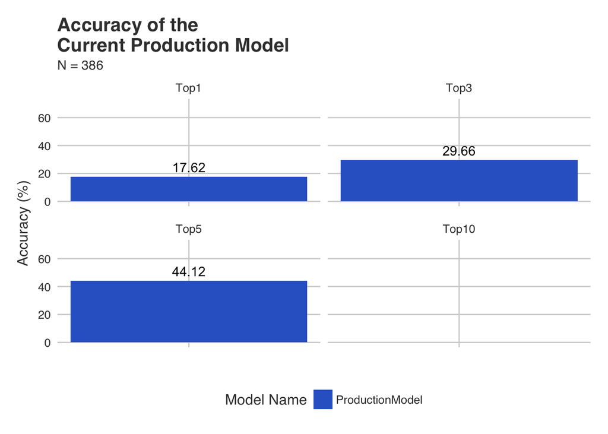

# First Pass Model

The first model turned in as a proof of concept is a very basic model - the steps:

1. Part-of-Speech tagging
2. Aggressive stopword removal
   - based on a large custom list (~850 words) and words with a POS tag belonging to a certain set
3. Lemmatization
4. TFIDF
   - vocabulary size of 12288
5. Scaling of TFIDF vectors
   - mean = 0, sd = 1
6. Naive Bayes classifier

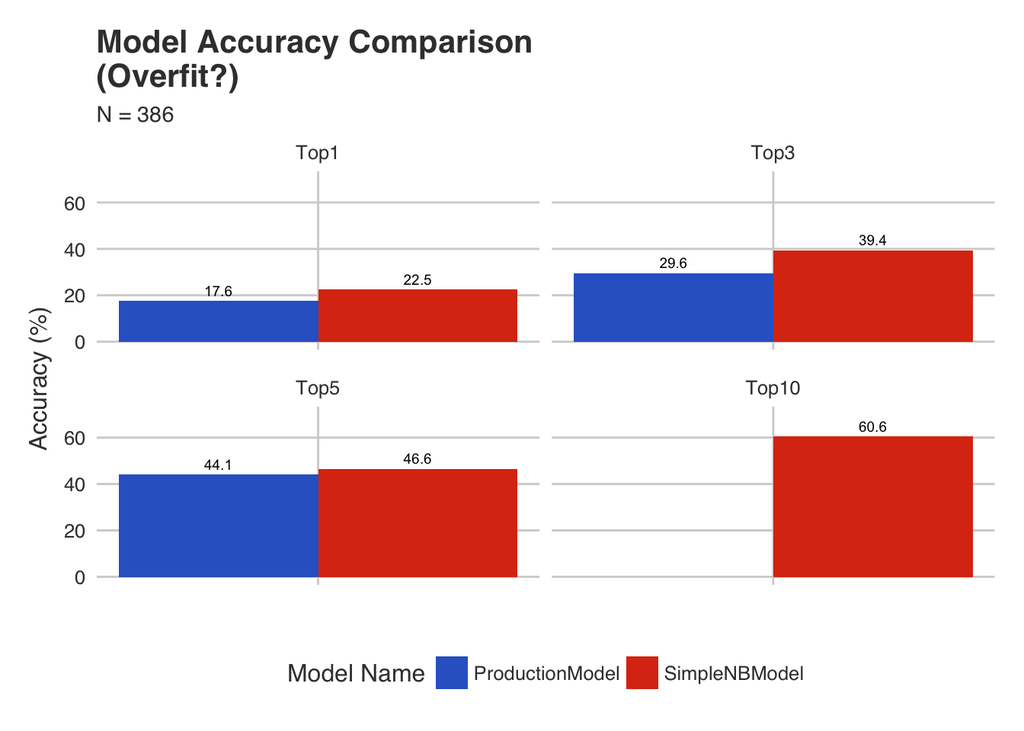

Unfortunately most of the examples in this set were likely used to train the naive bayes model (didn’t have time to check). However, it’s also possible that some of them were used to train the production algorithm, but we will give it a pass on that as we cannot know. I didn’t have a chance to retrain without those examples in the training set, so here is a comparison of the **production model accuracy on the 386 matches, vs the naive bayes model on a held out test set**:

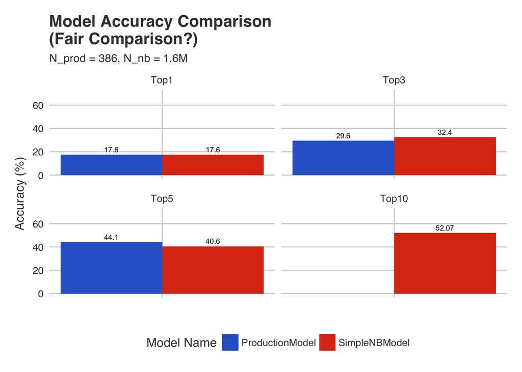

# Convolutional Neural Network Based on Kim 2014

A paper from 2014 suggested using a convolutional neural network with word embeddings as inputs for document classification. I implemented this model using Keras (a frontend for Tensorflow). The results:

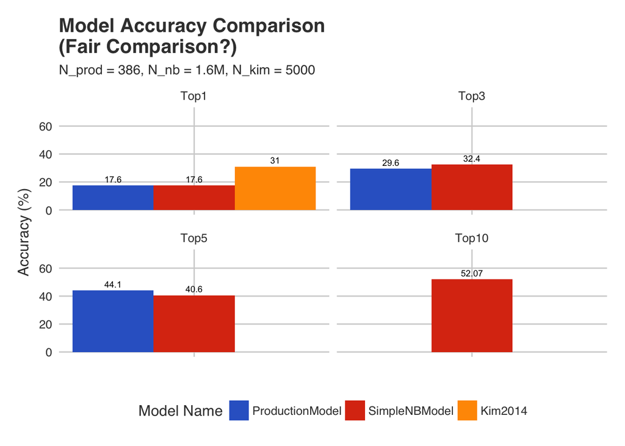

# Fasttext with Embeddings

Facebook more recently released deep learning approach based on word embeddings called fasttext. This is based on a Keras implementation, however there is a C++ version (with an open source java interface (not from facebook)).

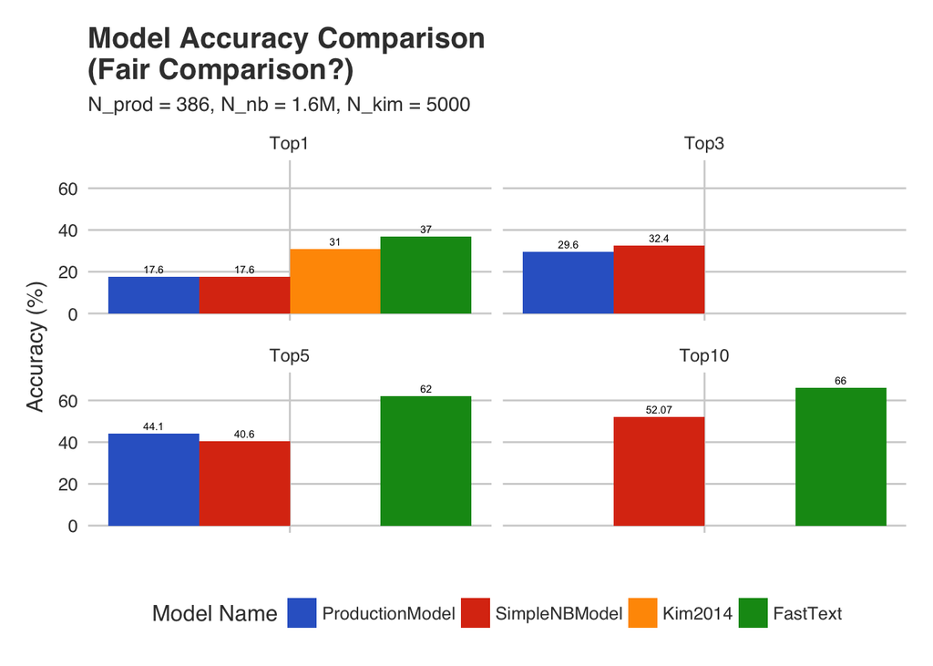